# Motor insurance analysis_2

Omar Sou’b

2023-12-29

# introduction

this analysis is conducted by using R-programming language as an analysis tool in the insurance industry, and specially for motor insurance .

the data set used called (datacar) and can be found on the (insurancedata) package on r.

**>we have also used packages such as:**

- tidyvarse.
- tidyr.
- janitor.
- knitr.
- insurancerating , and others.

**>what we are going to do ?**

- looking at the data summary and description on order to understand the shape of the data.
- calculating the claims cost and group it by factors.
- calculating the claims count and group it by factors.
- calculating the total exposure and group it by factors.
- calculating the frequency cost and group it by factors.
- calculating the average severity cost and group it by factors.
- calculating the pure premium cost and group it by factors.
- calculating the rating factor for each.

**———————————————-**

# Part One: data set view,summary-descriptive analysis

## data set dimensions

lets have a look at the data set dimension :

```
## [1] 67856    10
```

| veh_value | exposure | clm | numclaims | claimcst0 | veh_body | veh_age | gender | area | agecat |
| --- | --- | --- | --- | --- | --- | --- | --- | --- | --- |
| 1.06 | 0.3039014 | 0 | 0 | 0 | HBACK | 3 | F | C | 2 |
| 1.03 | 0.6488706 | 0 | 0 | 0 | HBACK | 2 | F | A | 4 |
| 3.26 | 0.5694730 | 0 | 0 | 0 | UTE | 2 | F | E | 2 |
| 4.14 | 0.3175907 | 0 | 0 | 0 | STNWG | 2 | F | D | 2 |
| 0.72 | 0.6488706 | 0 | 0 | 0 | HBACK | 4 | F | C | 2 |
| 2.01 | 0.8542094 | 0 | 0 | 0 | HDTOP | 3 | M | C | 4 |

## data set variables types

lets have a look at the variables types:

```
## Rows: 67,856
## Columns: 10
## $ veh_value <dbl> 1.06, 1.03, 3.26, 4.14, 0.72, 2.01, 1.60, 1.47, 0.52, 0.38, …
## $ exposure  <dbl> 0.30390144, 0.64887064, 0.56947296, 0.31759069, 0.64887064, …
## $ clm       <int> 0, 0, 0, 0, 0, 0, 0, 0, 0, 0, 0, 0, 0, 0, 1, 0, 1, 1, 0, 0, …
## $ numclaims <int> 0, 0, 0, 0, 0, 0, 0, 0, 0, 0, 0, 0, 0, 0, 1, 0, 1, 1, 0, 0, …
## $ claimcst0 <dbl> 0.0000, 0.0000, 0.0000, 0.0000, 0.0000, 0.0000, 0.0000, 0.00…
## $ veh_body  <fct> HBACK, HBACK, UTE, STNWG, HBACK, HDTOP, PANVN, HBACK, HBACK,…
## $ veh_age   <int> 3, 2, 2, 2, 4, 3, 3, 2, 4, 4, 2, 3, 2, 1, 3, 2, 3, 3, 4, 3, …
## $ gender    <fct> F, F, F, F, F, M, M, M, F, F, M, M, F, M, M, M, F, M, F, F, …
## $ area      <fct> C, A, E, D, C, C, A, B, A, B, A, C, C, A, B, C, F, C, D, C, …
## $ agecat    <int> 2, 4, 2, 2, 2, 4, 4, 6, 3, 4, 2, 4, 4, 5, 6, 4, 4, 4, 2, 3, …
```

now we will make some data transformation,will do the below :

1. convert agecat & veh_age types into factor
2. create a new variable called: veh_value_group

lets look again to the variables types :

```
## Rows: 67,856
## Columns: 11
## $ veh_value       <dbl> 1.06, 1.03, 3.26, 4.14, 0.72, 2.01, 1.60, 1.47, 0.52, …
## $ exposure        <dbl> 0.30390144, 0.64887064, 0.56947296, 0.31759069, 0.6488…
## $ clm             <int> 0, 0, 0, 0, 0, 0, 0, 0, 0, 0, 0, 0, 0, 0, 1, 0, 1, 1, …
## $ numclaims       <int> 0, 0, 0, 0, 0, 0, 0, 0, 0, 0, 0, 0, 0, 0, 1, 0, 1, 1, …
## $ claimcst0       <dbl> 0.0000, 0.0000, 0.0000, 0.0000, 0.0000, 0.0000, 0.0000…
## $ veh_body        <fct> HBACK, HBACK, UTE, STNWG, HBACK, HDTOP, PANVN, HBACK, …
## $ veh_age         <fct> 3, 2, 2, 2, 4, 3, 3, 2, 4, 4, 2, 3, 2, 1, 3, 2, 3, 3, …
## $ gender          <fct> F, F, F, F, F, M, M, M, F, F, M, M, F, M, M, M, F, M, …
## $ area            <fct> C, A, E, D, C, C, A, B, A, B, A, C, C, A, B, C, F, C, …
## $ agecat          <fct> 2, 4, 2, 2, 2, 4, 4, 6, 3, 4, 2, 4, 4, 5, 6, 4, 4, 4, …
## $ veh_value_group <fct> group 1, group 1, group 1, group 1, group 1, group 1, …
```

## data set summary and distribution

lets have the data summary and the variables distribution :

|  | veh_value | exposure | clm | numclaims | claimcst0 | veh_body | veh_age | gender | area | agecat | veh_value_group |
| --- | --- | --- | --- | --- | --- | --- | --- | --- | --- | --- | --- |
|  | Min. : 0.000 | Min. :0.002738 | Min. :0.00000 | Min. :0.00000 | Min. : 0.0 | SEDAN :22233 | 1:12257 | F:38603 | A:16312 | 1: 5742 | group 1:67779 |
|  | 1st Qu.: 1.010 | 1st Qu.:0.219028 | 1st Qu.:0.00000 | 1st Qu.:0.00000 | 1st Qu.: 0.0 | HBACK :18915 | 2:16587 | M:29253 | B:13341 | 2:12875 | group 2: 70 |
|  | Median : 1.500 | Median :0.446270 | Median :0.00000 | Median :0.00000 | Median : 0.0 | STNWG :16261 | 3:20064 | NA | C:20540 | 3:15767 | group 3: 6 |
|  | Mean : 1.777 | Mean :0.468651 | Mean :0.06814 | Mean :0.07276 | Mean : 137.3 | UTE : 4586 | 4:18948 | NA | D: 8173 | 4:16189 | group 4: 1 |
|  | 3rd Qu.: 2.150 | 3rd Qu.:0.709103 | 3rd Qu.:0.00000 | 3rd Qu.:0.00000 | 3rd Qu.: 0.0 | TRUCK : 1750 | NA | NA | E: 5912 | 5:10736 | NA |
|  | Max. :34.560 | Max. :0.999316 | Max. :1.00000 | Max. :4.00000 | Max. :55922.1 | HDTOP : 1579 | NA | NA | F: 3578 | 6: 6547 | NA |
|  | NA | NA | NA | NA | NA | (Other): 2532 | NA | NA | NA | NA | NA |

### Numerical variables

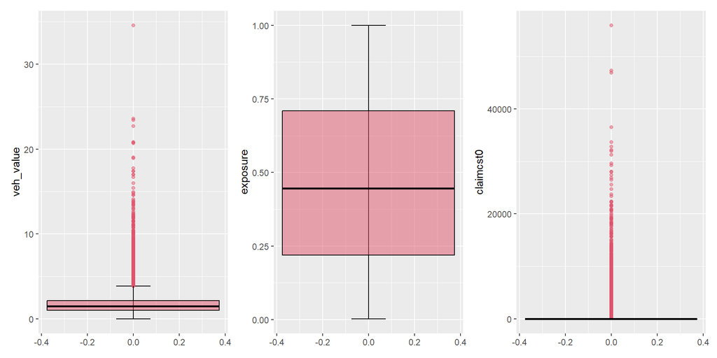

### categotical variables

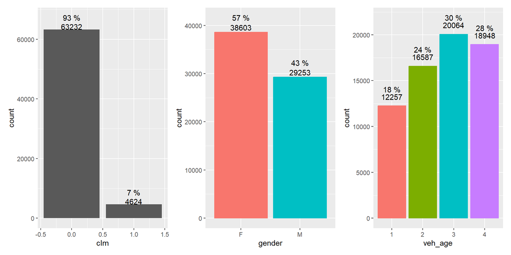

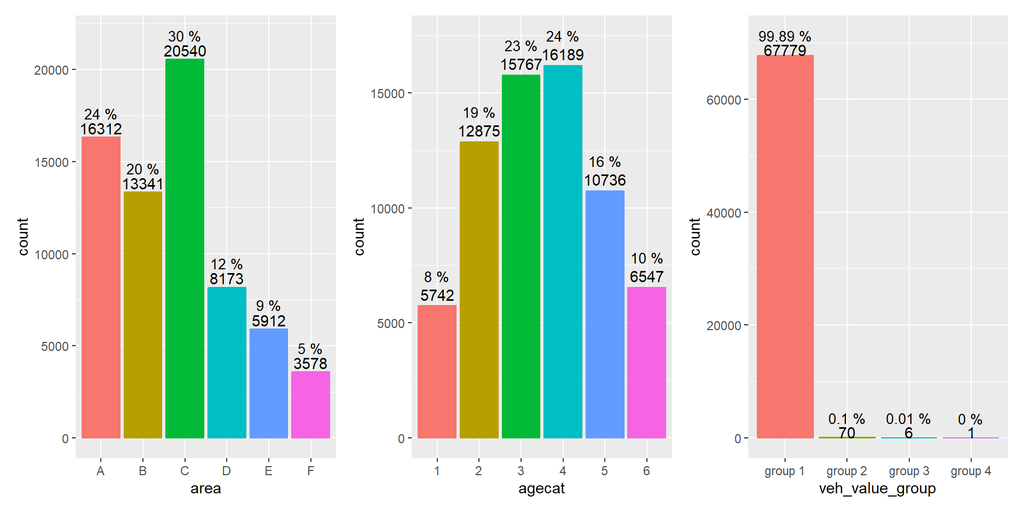

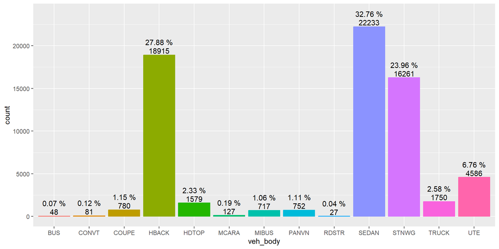

- 7% of the vehicles in this data had claims .
- 43% of the data samples are for males and 57% are for females.
- more than 50% of our vehicles are old (3 & 4 ages) and only 18% are brand new vehicles.
- area C has the highest number of customers with 30 % , and area F has the lowest 5%.
- more than 45% of the customers are located in the age group 3 & 4.
- more than 99% of our vehicles values are within group 1.
- sedan vehicles has the highest percentage with 32% ,and (Bus,CONVT,MCARA,RDSTR) has the lowest with less than 1%.

**———————————————-**

# Part Two: insurance risk measurements by factors.

as the insurance risk level is measured by the frequency and the severity; we will calculate the the same and group it by factors.

## gender factor

| gender | claimcst0 | numclaims | exposure | frequency | average_severity | risk_premium |
| --- | --- | --- | --- | --- | --- | --- |
| F | 4908749 | 2832 | 17954.60 | 0.1577311 | 1733.315 | 273.3978 |
| M | 4405855 | 2105 | 13846.21 | 0.1520271 | 2093.043 | 318.1993 |

> we can see that :
- females number of claims are more than males.
- females claims cost are more than males but; the average severity is less ,and this is due to the larger number of claims(more than males)
- both females and males almost have the same frequency.
- female risk premium is lesser than males ,and this due to the higher exposure females have

the below chart visualize all together for more clear understanding:

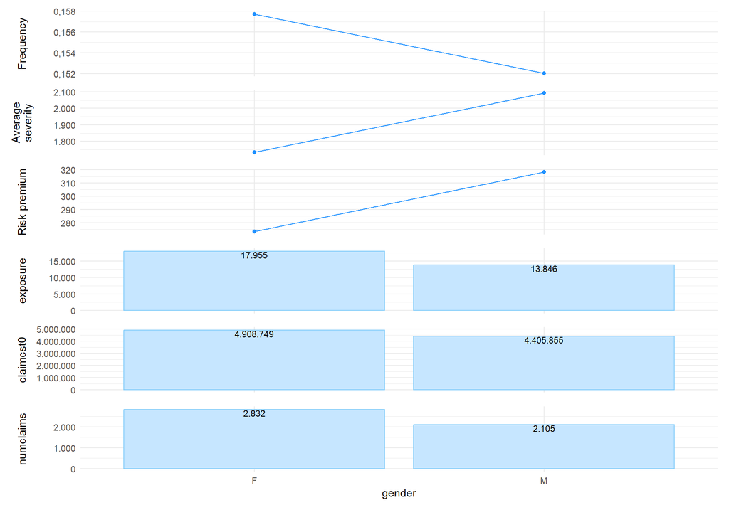

## veh_age factor

| veh_age | claimcst0 | numclaims | exposure | frequency | average_severity | risk_premium |
| --- | --- | --- | --- | --- | --- | --- |
| 3 | 2718237 | 1446 | 9542.111 | 0.1515388 | 1879.832 | 284.8675 |
| 2 | 2486217 | 1354 | 7923.677 | 0.1708803 | 1836.202 | 313.7706 |
| 4 | 2554895 | 1261 | 8996.079 | 0.1401722 | 2026.087 | 284.0010 |
| 1 | 1555255 | 876 | 5338.951 | 0.1640772 | 1775.405 | 291.3034 |

> we can see that :
- the claims cost for the vehicle age 1 is the lowest while for vehicle age 3 is the highest.
- vehicle age 1 has the lowest number on claims while the vehicle age 3 has the highest.
- the exposure for the vehicle age 1 is the lowest while for vehicle age 3 is the highest.
- the frequency for the vehicle age 4 is the lowest while for vehicle age 2 is the highest.
- the average_severity for the vehicle age 1 is the lowest while for vehicle age 4 is the highest.
- the risk premium for the vehicle age 3 & 4 is the lowest and almost the same, while its the highest for vehicle age 2

the below chart visualize all together for more clear understating :

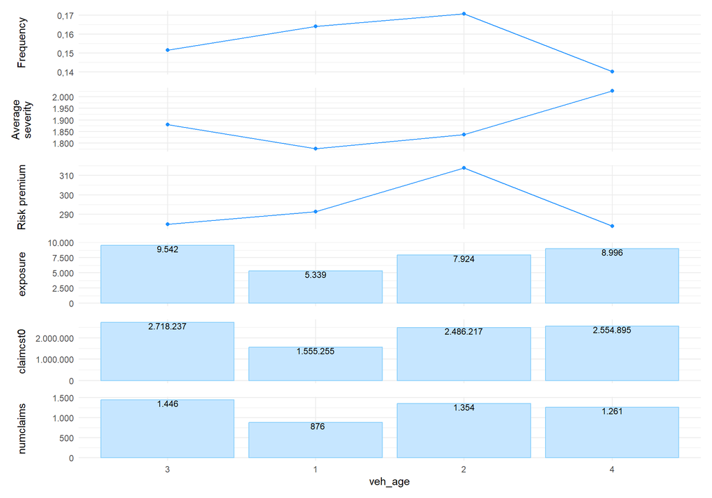

## veh_body

| veh_body | claimcst0 | numclaims | exposure | frequency | average_severity | risk_premium |
| --- | --- | --- | --- | --- | --- | --- |
| HBACK | 2589136.192 | 1330 | 8810.31348 | 0.1509594 | 1946.7189 | 293.8756 |
| UTE | 597208.965 | 276 | 2105.73032 | 0.1310709 | 2163.8006 | 283.6113 |
| STNWG | 2363091.211 | 1248 | 7638.39014 | 0.1633852 | 1893.5026 | 309.3703 |
| HDTOP | 294811.869 | 136 | 783.29911 | 0.1736246 | 2167.7343 | 376.3720 |
| PANVN | 133113.412 | 68 | 409.16085 | 0.1661938 | 1957.5502 | 325.3327 |
| SEDAN | 2681622.477 | 1598 | 10444.59959 | 0.1529977 | 1678.1117 | 256.7473 |
| TRUCK | 319496.849 | 130 | 843.96441 | 0.1540349 | 2457.6681 | 378.5667 |
| COUPE | 187723.251 | 75 | 319.12663 | 0.2350164 | 2502.9767 | 588.2406 |
| MIBUS | 116104.880 | 45 | 316.84052 | 0.1420273 | 2580.1084 | 366.4458 |
| MCARA | 10673.950 | 15 | 59.27995 | 0.2530367 | 711.5967 | 180.0601 |
| BUS | 13363.120 | 10 | 25.84805 | 0.3868764 | 1336.3120 | 516.9876 |
| CONVT | 6888.810 | 3 | 32.59685 | 0.0920334 | 2296.2700 | 211.3336 |
| RDSTR | 1369.458 | 3 | 11.66872 | 0.2570976 | 456.4861 | 117.3615 |

the below chart visualize all together for more clear understanding:

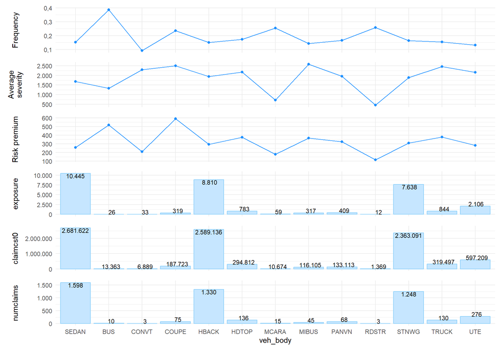

## area

| area | claimcst0 | numclaims | exposure | frequency | average_severity | risk_premium |
| --- | --- | --- | --- | --- | --- | --- |
| C | 2865707.2 | 1493 | 9578.494 | 0.1558700 | 1919.429 | 299.1814 |
| A | 2071765.6 | 1181 | 7597.101 | 0.1554540 | 1754.247 | 272.7048 |
| E | 868822.9 | 413 | 2771.866 | 0.1489971 | 2103.687 | 313.4434 |
| D | 911058.2 | 524 | 3819.518 | 0.1371901 | 1738.661 | 238.5270 |
| B | 1795295.2 | 1021 | 6297.848 | 0.1621189 | 1758.369 | 285.0649 |
| F | 801955.4 | 305 | 1735.992 | 0.1756921 | 2629.362 | 461.9581 |

> we can see that :
- the lowest claims cost is for area F , and the highest cost is for area C.
- area F has the lowest number of claims , while area C has the highest .
- area D has the lowest frequency , while area F has the highest.
- area D has the lowest average frequency ,while area F has the highest.
- area D has the lowest risk premium , while area F has the highest.

the below chart visualize all together for more clear understanding:

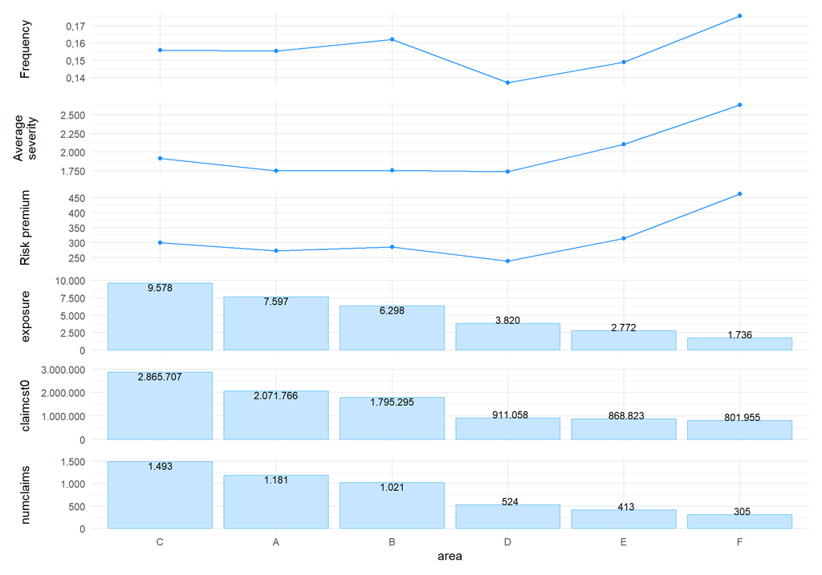

## age category

| agecat | claimcst0 | numclaims | exposure | frequency | average_severity | risk_premium |
| --- | --- | --- | --- | --- | --- | --- |
| 2 | 1984840.8 | 1000 | 5891.871 | 0.1697254 | 1984.841 | 336.8778 |
| 4 | 2145303.0 | 1185 | 7616.542 | 0.1555824 | 1810.382 | 281.6636 |
| 6 | 683568.5 | 390 | 3099.666 | 0.1258200 | 1752.740 | 220.5297 |
| 3 | 2132107.1 | 1189 | 7409.457 | 0.1604706 | 1793.194 | 287.7549 |
| 5 | 1061412.2 | 648 | 5171.009 | 0.1253140 | 1637.982 | 205.2621 |
| 1 | 1307372.9 | 525 | 2612.274 | 0.2009743 | 2490.234 | 500.4732 |

> we can see that :
- age category 6 has the lowest claims cost , while age category 4 has the highest
- age category 6 has the lowest number of claims , while age category 4 & 3 has the highest (1185,1189) .
- age category 6 & 5 has the lowest frequency with almost(12.5%) , while age category 1 has the highest with 20%.
- age category 5 has the lowest average frequency ,while age category 1 has the highest.
- age category 5 has the lowest risk premium , while age category 1 has the highest.

the below chart visualize all together for more clear understanding:

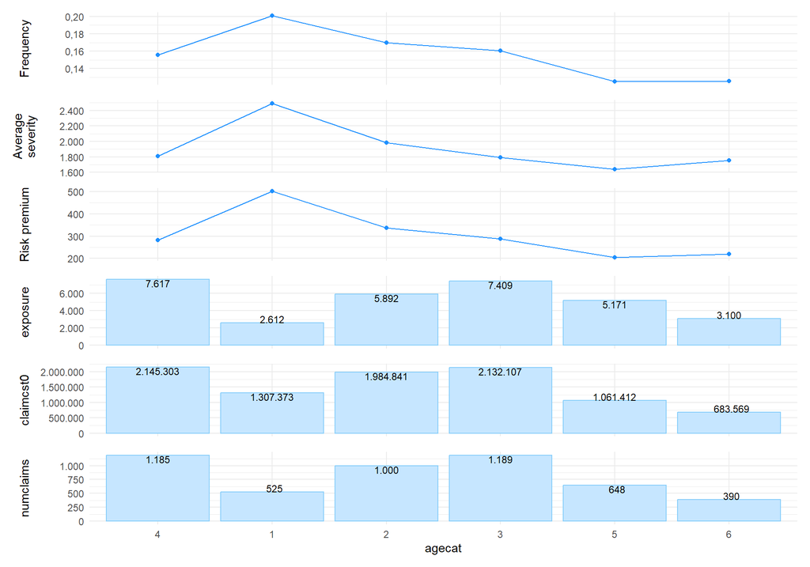

```
## $statistics
##                           aic      bic bayes.factor      p
## numclaims_glm_all    34822.37 35068.75 0.000000e+00 <2e-16
## numclaims_glm_agecat 34862.03 34916.78 1.002062e+33
##
## $predicted_differences
##    0%   25%   50%   75%  100%
## 0.000 0.001 0.004 0.009 0.247
```

```
## $statistics
##                         aic      bic bayes.factor      p
## numclaims_glm_all  34822.37 35068.75 0.000000e+00 <2e-16
## numclaims_glm_area 34938.22 34992.97 2.858943e+16
##
## $predicted_differences
##    0%   25%   50%   75%  100%
## 0.000 0.002 0.006 0.014 0.284
```

```
## $statistics
##                           aic      bic bayes.factor      p
## numclaims_glm_all    34822.37 35068.75 0.000000e+00 <2e-16
## numclaims_glm_gender 34944.03 34962.28 1.317565e+23
##
## $predicted_differences
##    0%   25%   50%   75%  100%
## 0.000 0.002 0.007 0.015 0.282
```

```
## $statistics
##                            aic      bic bayes.factor      p
## numclaims_glm_all     34822.37 35068.75 0.000000e+00 <2e-16
## numclaims_glm_veh_age 34920.50 34957.00 1.850433e+24
##
## $predicted_differences
##    0%   25%   50%   75%  100%
## 0.000 0.002 0.006 0.013 0.287
```

```
## $statistics
##                             aic      bic bayes.factor      p
## numclaims_glm_all      34822.37 35068.75         0.00 <2e-16
## numclaims_glm_veh_body 34930.11 35048.74     22196.62
##
## $predicted_differences
##    0%   25%   50%   75%  100%
## 0.000 0.002 0.006 0.014 0.132
```

> from our results we can say that the numclaims_glm_all model is best .

lets apply the anova function on the model so we can well know how much the variables are important to the model

```
## Analysis of Deviance Table
##
## Model: poisson, link: log
##
## Response: numclaims
##
## Terms added sequentially (first to last)
##
##
##          Df Deviance Resid. Df Resid. Dev  Pr(>Chi)
## NULL                     67855      25507
## veh_body 12   37.563     67843      25469  0.000181 ***
## veh_age   3   33.543     67840      25436 2.474e-07 ***
## gender    1    1.595     67839      25434  0.206575
## area      5   14.525     67834      25420  0.012598 *
## agecat    5   86.074     67829      25334 < 2.2e-16 ***
## ---
## Signif. codes:  0 '***' 0.001 '**' 0.01 '*' 0.05 '.' 0.1 ' ' 1
```

so the gender variable has the least impact on the model

**—————————–**

# Part Three: claims count response to the predictors variables

the below chart express visually how number of claims will act (decrease on increase)-along with the lower and upper confident intervals-, when any of the factors increase by one unit:

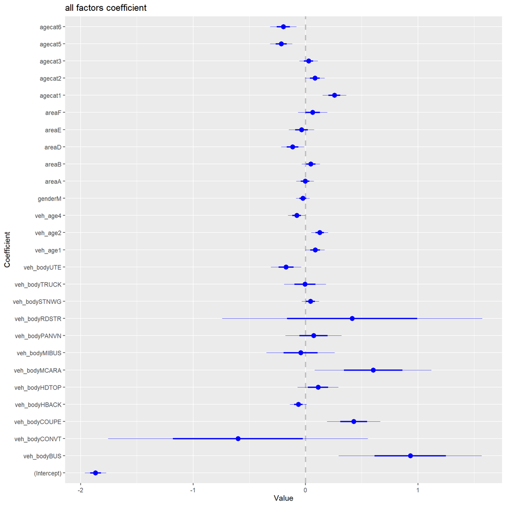

> if any factor increases by one unit ;the number of claims will increase or decrease by the coefficient value for the same factor.

**—————————–**

# Part four: rating factors

now;lets look at the rating factor for the new model (numclaims_glm_all) which is the best performed model:

```
## Significance levels: *** p < 0.001; ** p < 0.01;
##     * p < 0.05; . p < 0.1
```

| risk_factor | level | est_numclaims_glm_all | exposure |
| --- | --- | --- | --- |
| (Intercept) | (Intercept) | 0.154456 | NA |
| veh_body | BUS | 2.539240 ** | 26 |
| veh_body | CONVT | 0.548256 | 33 |
| veh_body | COUPE | 1.534809 *** | 319 |
| veh_body | HBACK | 0.938495 . | 8810 |
| veh_body | HDTOP | 1.117535 | 783 |
| veh_body | MCARA | 1.824920 * | 59 |
| veh_body | MIBUS | 0.957521 | 317 |
| veh_body | PANVN | 1.074029 | 409 |
| veh_body | RDSTR | 1.513937 | 12 |
| veh_body | SEDAN | 1.000000 | 10445 |
| veh_body | STNWG | 1.045286 | 7638 |
| veh_body | TRUCK | 0.995693 | 844 |
| veh_body | UTE | 0.840990 ** | 2106 |
| veh_age | 1 | 1.089375 * | 5339 |
| veh_age | 2 | 1.134451 *** | 7924 |
| veh_age | 3 | 1.000000 | 9542 |
| veh_age | 4 | 0.925126 * | 8996 |
| gender | F | 1.000000 | 17955 |
| gender | M | 0.976814 | 13846 |
| area | A | 0.996318 | 7597 |
| area | B | 1.048834 | 6298 |
| area | C | 1.000000 | 9578 |
| area | D | 0.891774 * | 3820 |
| area | E | 0.965319 | 2772 |
| area | F | 1.065872 | 1736 |
| agecat | 1 | 1.293463 *** | 2612 |
| agecat | 2 | 1.087360 . | 5892 |
| agecat | 3 | 1.027766 | 7409 |
| agecat | 4 | 1.000000 | 7617 |
| agecat | 5 | 0.805326 *** | 5171 |
| agecat | 6 | 0.820623 *** | 3100 |

on graph:

```
## Significance levels: *** p < 0.001; ** p < 0.01;
##     * p < 0.05; . p < 0.1
```

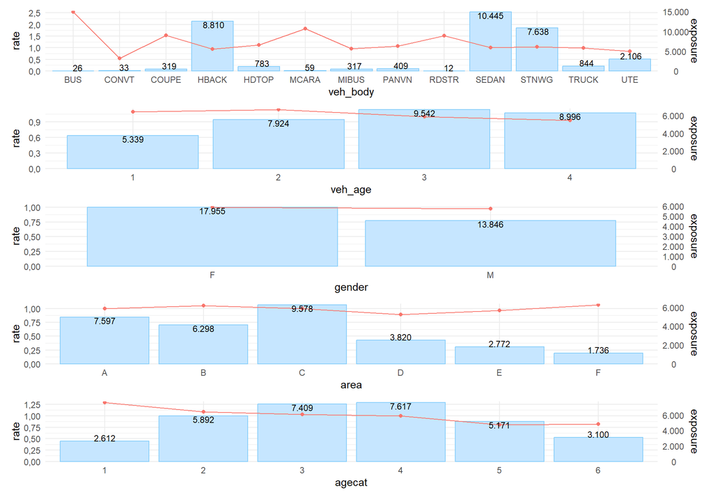

**—————————–**

# Conclusion:

## preferred segments

- area : D.
- agecat : 5,6
- veh_body : UTE,CONVT.

## the high risk segments

- veh_body : BUS,COUPE,MACARA,RDSTS